# ANALYSIS OF MEASLES CASES OVER TIME WITH RELATION TO MEASLES VACCINATION

[figure not shown]

```r
knitr::include_graphics("C:/Users/hp/Downloads/data viz/thd-logo.jpg")
```

- **STUDENT**: Shefali Badre ; **MATRICULATION NUMBER**: 22203735 ; **EMAIL ID**: shefali.badre@stud.th-deg.de
- **STUDENT**: Shraddha Karambelkar ; **MATRICULATION NUMBER**: 22204857 ; **EMAIL ID**: shraddha.karambelkar@stud.th-deg.de

**ABOUT PROJECT TYCHO**

For this project we are using **Project Tycho Level 2 Data Version 1.1.0** which contains 50 diseases from all 50 states in the USA (which is approximately 1284 US cities) from the year 1888 to 2014.<sup>[0]</sup> Project Tycho is global health data platform which collects public health data from different health agencies and researchers and use the data to improve health informatics. Its mainly focus is on infectious diseases and epidemics.

1. **INTRODUCTION**

Measles is a highly contagious, serious disease caused by a virus of the *paramyxovirus* family<sup>[1]</sup>. The disease has an incubation period of 8 - 12 days, and then presents with increasing fever (up to 39 - 40.5 degrees celsius), cough, coryza and conjunctivitis. The symptoms intensify over 2 - 4 days before the onset of rash and peak on the day one of rash. The rash usually appears first on the face and neck as discrete erythematous patches. The number increases for 2 - 3 days, mostly on the trunk and face. Discrete lesions are also usually found on the distal extremities. The rash lasts for 3- 7 days before disappearing<sup>[2]</sup>.

Since the introduction of measles vaccine in 1963, CDC (Center for Disease Control) of USA began its effort to fight this illness. By the year 2000 the efforts paid off and US declared measles eliminated.<sup>[0]</sup>

Even though a safe and cost effective vaccine is available, in 2021, there were an estimated 128,000 deaths globally, mostly among non-vaccinated children under the age of 5. In that same year, only about 81% of children received one dose of the measles vaccine by their first birthday, the lowest since 2008<sup>[3]</sup>. In the year 2022, in Columbus, Ohio, there was a Measles outbreak fueled by increasing vaccine hesitancy owing to increased anti-vaccine sentiment sparked by conspiracy theories surrounding the COVID-19 pandemic<sup>[4]</sup>.

Our analysis is aimed at presenting cases before and after the introduction of the **Measles Containing Vaccine (MCV)** in the hopes that it will dispel the reservations of parents who might be hesitant about allowing their children to receive the vaccine.

2. **PROBLEM STATEMENT**

Given that 2021 was the year with the lowest immunization rate for Measles in children globally since 2008, and that 2022 saw an outbreak of measles in the United States, owing to increased vaccine-skepticism, we present the incidence of Measles cases over the years in an attempt to let the data speak for itself to vaccine skeptics on the efficacy and necessity of measles vaccination.

3. **OBJECTIVES**
- To show data on measles incidence from the 20th to the 21st century
- To highlight the sharp decline in the incidence of measles after the introduction of the Measles Vaccine
- To show small up shoots in the incidence of measles when vaccination rates falls
- To make recommendation for further studies
4. **METHODS**

We made use of the following packages for comprehensive analysis:

- For cleaning our data: tidyverse, lubridate, readxl(to read excel data)
- For graphs: ggplot2, usmaps, patchwork
- For inferential statistics: Pearson test for correlation
- News articles for insight into growing anti-vaccination sentiment
- Vaccination data from the WHO and UNICEF

4.1. **ANALYSIS**

4.4.1 **Data Loading and Data Clean-up**

We load our data initially with an absolute path

```r
dataTycho<-read.csv("C:/Users/hp/Downloads/data viz/ProjectTycho_Level2_v1.1.0.csv")
```

We get a look at the data inside our project Tycho dataframe

```r
dataTycho
```

| epi_week | country | state | loc | loc_type | disease | event | number | from_date | to_date | url |
| --- | --- | --- | --- | --- | --- | --- | --- | --- | --- | --- |
| 188824 | US | PA | PHILADELPHIA | CITY | TYPHOID FEVER [ENTERIC FEVER] | DEATHS | 14 | 1888-06-10 | 1888-06-16 | http://www.ncbi.nlm.nih.gov/pmc/articles/PMC2084171 |
| 188824 | US | PA | PHILADELPHIA | CITY | SCARLET FEVER | DEATHS | 4 | 1888-06-10 | 1888-06-16 | http://www.ncbi.nlm.nih.gov/pmc/articles/PMC2084171 |
| 188824 | US | PA | PHILADELPHIA | CITY | DIPHTHERIA | DEATHS | 4 | 1888-06-10 | 1888-06-16 | http://www.ncbi.nlm.nih.gov/pmc/articles/PMC2084171 |
| 188826 | US | PA | PHILADELPHIA | CITY | TYPHOID FEVER [ENTERIC FEVER] | DEATHS | 12 | 1888-06-24 | 1888-06-30 | http://www.ncbi.nlm.nih.gov/pmc/articles/PMC2084171 |
| 188826 | US | PA | PHILADELPHIA | CITY | SCARLET FEVER | DEATHS | 5 | 1888-06-24 | 1888-06-30 | http://www.ncbi.nlm.nih.gov/pmc/articles/PMC2084171 |
| 188826 | US | PA | PHILADELPHIA | CITY | DIPHTHERIA | DEATHS | 7 | 1888-06-24 | 1888-06-30 | http://www.ncbi.nlm.nih.gov/pmc/articles/PMC2084171 |
| 188826 | US | MD | BALTIMORE | CITY | TYPHOID FEVER [ENTERIC FEVER] | DEATHS | 4 | 1888-06-24 | 1888-06-30 | http://www.ncbi.nlm.nih.gov/pmc/articles/PMC2084171 |
| 188826 | US | MD | BALTIMORE | CITY | DIPHTHERIA | DEATHS | 1 | 1888-06-24 | 1888-06-30 | http://www.ncbi.nlm.nih.gov/pmc/articles/PMC2084171 |
| 188825 | US | LA | NEW ORLEANS | CITY | TYPHOID FEVER [ENTERIC FEVER] | DEATHS | 1 | 1888-06-17 | 1888-06-23 | http://www.ncbi.nlm.nih.gov/pmc/articles/PMC2084171 |
| 188825 | US | LA | NEW ORLEANS | CITY | DIPHTHERIA | DEATHS | 4 | 1888-06-17 | 1888-06-23 | http://www.ncbi.nlm.nih.gov/pmc/articles/PMC2084171 |

[output cut: 990 more lines]

To clean up the data, we install the tidyverse package. We’ve commented the code out because in R for Data Science, we should avoid leaving in code that might change the settings on someone else’s computer if we mean to send our project to someone else.

```r
#install.packages("tidyverse")
```

Here we load the tidyverse library

```r
library(tidyverse)
```

We filter the Measles data we need from the Tycho dataset using the filter() function of the tidy verse library and assign it to the dataframe “usMeasles”

```r
usMeasles <- filter(dataTycho, disease == "MEASLES")
```

We take a peek at our usMeasles dataframe

```r
usMeasles
```

| epi_week | country | state | loc | loc_type | disease | event | number | from_date | to_date | url |
| --- | --- | --- | --- | --- | --- | --- | --- | --- | --- | --- |
| 190640 | US | MD | BALTIMORE | CITY | MEASLES | CASES | 6 | 1906-09-30 | 1906-10-06 | http://www.ncbi.nlm.nih.gov/pmc/articles/PMC2081022 |
| 190640 | US | MA | BOSTON | CITY | MEASLES | CASES | 1 | 1906-09-30 | 1906-10-06 | http://www.ncbi.nlm.nih.gov/pmc/articles/PMC2081022 |
| 190640 | US | MA | CHELSEA | CITY | MEASLES | CASES | 1 | 1906-09-30 | 1906-10-06 | http://www.ncbi.nlm.nih.gov/pmc/articles/PMC2081022 |
| 190640 | US | IL | CHICAGO | CITY | MEASLES | CASES | 2 | 1906-09-30 | 1906-10-06 | http://www.ncbi.nlm.nih.gov/pmc/articles/PMC2081022 |
| 190640 | US | OH | CINCINNATI | CITY | MEASLES | CASES | 1 | 1906-09-29 | 1906-10-05 | http://www.ncbi.nlm.nih.gov/pmc/articles/PMC2081022 |
| 190640 | US | NY | ELMIRA | CITY | MEASLES | CASES | 1 | 1906-09-30 | 1906-10-06 | http://www.ncbi.nlm.nih.gov/pmc/articles/PMC2081022 |
| 190640 | US | PA | JOHNSTOWN | CITY | MEASLES | CASES | 1 | 1906-09-30 | 1906-10-06 | http://www.ncbi.nlm.nih.gov/pmc/articles/PMC2081022 |
| 190640 | US | MA | LOWELL | CITY | MEASLES | CASES | 2 | 1906-09-30 | 1906-10-06 | http://www.ncbi.nlm.nih.gov/pmc/articles/PMC2081022 |
| 190640 | US | PA | MCKEESPORT | CITY | MEASLES | CASES | 1 | 1906-09-30 | 1906-10-06 | http://www.ncbi.nlm.nih.gov/pmc/articles/PMC2081022 |
| 190640 | US | NY | MOUNT VERNON | CITY | MEASLES | CASES | 4 | 1906-09-30 | 1906-10-06 | http://www.ncbi.nlm.nih.gov/pmc/articles/PMC2081022 |

[output cut: 990 more lines]

We can see that the from_data and to_date variables are type character but we need them to be type date. To do this, we load the lubridate library

```r
library(lubridate)
```

We use the ymd() function from lubridate in conjunction with the mutate() function from tidyverse to achieve our conversion of the from_date and to_date variables to data type date.

```r
usMeasles <- mutate(usMeasles, from_date = ymd(from_date),
                    to_date = ymd(to_date))
```

We look into our usMeasles data frame again to check if from_date and to_date have been successfully converted. Their data type is now date.

```r
usMeasles
```

| epi_week | country | state | loc | loc_type | disease | event | number | from_date | to_date | url |
| --- | --- | --- | --- | --- | --- | --- | --- | --- | --- | --- |
| 190640 | US | MD | BALTIMORE | CITY | MEASLES | CASES | 6 | 1906-09-30 | 1906-10-06 | http://www.ncbi.nlm.nih.gov/pmc/articles/PMC2081022 |
| 190640 | US | MA | BOSTON | CITY | MEASLES | CASES | 1 | 1906-09-30 | 1906-10-06 | http://www.ncbi.nlm.nih.gov/pmc/articles/PMC2081022 |
| 190640 | US | MA | CHELSEA | CITY | MEASLES | CASES | 1 | 1906-09-30 | 1906-10-06 | http://www.ncbi.nlm.nih.gov/pmc/articles/PMC2081022 |
| 190640 | US | IL | CHICAGO | CITY | MEASLES | CASES | 2 | 1906-09-30 | 1906-10-06 | http://www.ncbi.nlm.nih.gov/pmc/articles/PMC2081022 |
| 190640 | US | OH | CINCINNATI | CITY | MEASLES | CASES | 1 | 1906-09-29 | 1906-10-05 | http://www.ncbi.nlm.nih.gov/pmc/articles/PMC2081022 |
| 190640 | US | NY | ELMIRA | CITY | MEASLES | CASES | 1 | 1906-09-30 | 1906-10-06 | http://www.ncbi.nlm.nih.gov/pmc/articles/PMC2081022 |
| 190640 | US | PA | JOHNSTOWN | CITY | MEASLES | CASES | 1 | 1906-09-30 | 1906-10-06 | http://www.ncbi.nlm.nih.gov/pmc/articles/PMC2081022 |
| 190640 | US | MA | LOWELL | CITY | MEASLES | CASES | 2 | 1906-09-30 | 1906-10-06 | http://www.ncbi.nlm.nih.gov/pmc/articles/PMC2081022 |
| 190640 | US | PA | MCKEESPORT | CITY | MEASLES | CASES | 1 | 1906-09-30 | 1906-10-06 | http://www.ncbi.nlm.nih.gov/pmc/articles/PMC2081022 |
| 190640 | US | NY | MOUNT VERNON | CITY | MEASLES | CASES | 4 | 1906-09-30 | 1906-10-06 | http://www.ncbi.nlm.nih.gov/pmc/articles/PMC2081022 |

[output cut: 990 more lines]

We arrange the data by date using the arrange() function from tidyverse

```r
usMeaslesArranged <- arrange(usMeasles, from_date)
```

We take a look at our data and ascertain that our data is now correctly arranged

```r
usMeaslesArranged
```

| epi_week | country | state | loc | loc_type | disease | event | number | from_date | to_date | url |
| --- | --- | --- | --- | --- | --- | --- | --- | --- | --- | --- |
| 190633 | US | PA | COLUMBIA | CITY | MEASLES | CASES | 1 | 1906-08-12 | 1906-08-18 | http://www.ncbi.nlm.nih.gov/pmc/articles/PMC2081023 |
| 190638 | US | PA | PHILADELPHIA | CITY | MEASLES | CASES | 9 | 1906-09-16 | 1906-09-22 | http://www.ncbi.nlm.nih.gov/pmc/articles/PMC2081022 |
| 190638 | US | PA | COLUMBIA | CITY | MEASLES | CASES | 1 | 1906-09-16 | 1906-09-22 | http://www.ncbi.nlm.nih.gov/pmc/articles/PMC2081023 |
| 190639 | US | PA | PHILADELPHIA | CITY | MEASLES | CASES | 7 | 1906-09-23 | 1906-09-29 | http://www.ncbi.nlm.nih.gov/pmc/articles/PMC2081022 |
| 190639 | US | ME | PORTLAND | CITY | MEASLES | CASES | 4 | 1906-09-23 | 1906-09-29 | http://www.ncbi.nlm.nih.gov/pmc/articles/PMC2081022 |
| 190639 | US | CA | SAN FRANCISCO | CITY | MEASLES | CASES | 7 | 1906-09-23 | 1906-09-29 | http://www.ncbi.nlm.nih.gov/pmc/articles/PMC2081022 |
| 190639 | US | PA | PITTSBURGH | CITY | MEASLES | CASES | 2 | 1906-09-23 | 1906-09-29 | http://www.ncbi.nlm.nih.gov/pmc/articles/PMC2081023 |
| 190639 | US | WA | TACOMA | CITY | MEASLES | CASES | 1 | 1906-09-24 | 1906-09-30 | http://www.ncbi.nlm.nih.gov/pmc/articles/PMC2081022 |
| 190640 | US | OH | CINCINNATI | CITY | MEASLES | CASES | 1 | 1906-09-29 | 1906-10-05 | http://www.ncbi.nlm.nih.gov/pmc/articles/PMC2081022 |
| 190640 | US | MD | BALTIMORE | CITY | MEASLES | CASES | 6 | 1906-09-30 | 1906-10-06 | http://www.ncbi.nlm.nih.gov/pmc/articles/PMC2081022 |

[output cut: 990 more lines]

We want to what US measles incidence per state is, so we need to group our data by state and get the total number of cases in each state. To do this, we use the group_by() and summarize() functions provided by tidyverse library and save our new data into the usMeaslesPerState dataframe

```r
usMeaslesPerState <- usMeaslesArranged %>%
                     group_by(state) %>%
                     summarize(case_per_state = sum(number, na.rm = TRUE))
```

We checkout the usMeaslesPerState dataframe

```r
usMeaslesPerState
```

| state | case_per_state |
| --- | --- |
| AK | 16761 |
| AL | 250589 |
| AR | 152047 |
| AS | 3 |
| AZ | 161901 |
| CA | 1690185 |
| CO | 351245 |
| CT | 456725 |
| DC | 166152 |
| DE | 45355 |

[output cut: 47 more lines]

To visualize our data, we require the usmap package

```r
#install.packages("usmap")
```

We load our the usmap package

```r
library(usmap)
```

The usmap package requires to variables to work. The first is fips, a representation of geographical locations in the United States with unique codes. The second variable is values, which in this case is the number of cases per state store in the case_per_state variable. We use the fips() function to convert our state into fips codes, then convert the fips codes into numeric data type and save it in a variable fips. We convert our case_per_state into numeric and save it in values.

```r
usMeaslesPerState <- usMeaslesPerState %>%
                     mutate(fips = as.numeric(fips(state)),
                            values = as.numeric(case_per_state))
```

We check our update usMeaslesPerState data frame and can now see the additional variables fips and values

```r
usMeaslesPerState
```

| state | case_per_state | fips | values |
| --- | --- | --- | --- |
| AK | 16761 | 2 | 16761 |
| AL | 250589 | 1 | 250589 |
| AR | 152047 | 5 | 152047 |
| AZ | 161901 | 4 | 161901 |
| CA | 1690185 | 6 | 1690185 |
| CO | 351245 | 8 | 351245 |
| CT | 456725 | 9 | 456725 |
| DC | 166152 | 11 | 166152 |
| DE | 45355 | 10 | 45355 |
| FL | 184742 | 12 | 184742 |

[output cut: 41 more lines]

We want to remove any NA cells in the fips variable of our dataframe. We use the filter() function with the !is.na() function.

```r
usMeaslesPerState <- usMeaslesPerState %>%
                    filter(!is.na(fips))
```

We check again to see that the NA values have been removed.

```r
usMeaslesPerState
```

| state | case_per_state | fips | values |
| --- | --- | --- | --- |
| AK | 16761 | 2 | 16761 |
| AL | 250589 | 1 | 250589 |
| AR | 152047 | 5 | 152047 |
| AZ | 161901 | 4 | 161901 |
| CA | 1690185 | 6 | 1690185 |
| CO | 351245 | 8 | 351245 |
| CT | 456725 | 9 | 456725 |
| DC | 166152 | 11 | 166152 |
| DE | 45355 | 10 | 45355 |
| FL | 184742 | 12 | 184742 |

[output cut: 41 more lines]

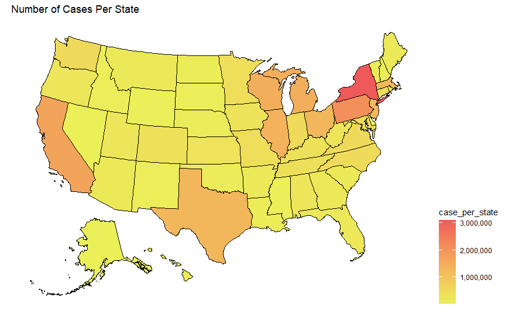

```r
plot_usmap(data = usMeaslesPerState) +
  scale_fill_continuous(low = "#ebf059", high = "#f05959", name = "case_per_state", label =   scales::comma) +
  labs(title = "Number of Cases Per State") +
  theme(legend.position = "right")
```

We can visualize this data better by using a bar chart. For that we only need our state and case_per_state variables

```r
usMeaslesPerState <- usMeaslesPerState %>%
                     select(state, case_per_state)
```

We check to see if our dataframe contains only the state and case_per_state variables

```r
usMeaslesPerState
```

| state | case_per_state |
| --- | --- |
| AK | 16761 |
| AL | 250589 |
| AR | 152047 |
| AZ | 161901 |
| CA | 1690185 |
| CO | 351245 |
| CT | 456725 |
| DC | 166152 |
| DE | 45355 |
| FL | 184742 |

[output cut: 41 more lines]

4.1.2 **Data Analysis of our DataSet**

We can now plot a bar chart on our dataframe. As stated earlier, we can see that New York, Pennsylvania and California have the highest peaks. The common factor amongst all these states is that they have very high populations. so the high incidence of measles cases there is not surprising giving their high populations

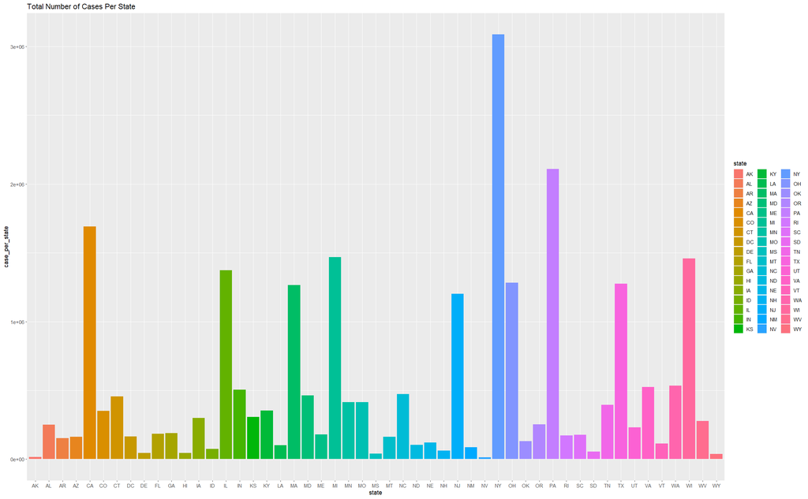

```r
ggplot(data = usMeaslesPerState, mapping = aes(x = state, y = case_per_state, fill = state)) +
  geom_bar(stat = "identity") +
  labs(title = "Total Number of Cases Per State")
```

Now we proceed to our mission of showcasing the incidence of measles over time. We group our usMeaslesArranged dataframe by year and summarize by total number of cases in each year and save it into a new dataframe

```r
usMeaslesPerYear <- usMeaslesArranged %>%
                    group_by(year = year(from_date)) %>%
                    summarize(case_per_year = sum(number))
```

We checkout the usMeaslesPerYear dataframe

```r
usMeaslesPerYear
```

| year | case_per_year |
| --- | --- |
| 1906 | 4590 |
| 1907 | 68134 |
| 1908 | 101213 |
| 1909 | 102696 |
| 1910 | 134981 |
| 1911 | 100458 |
| 1912 | 107386 |
| 1913 | 156167 |
| 1914 | 67339 |
| 1915 | 134745 |

[output cut: 86 more lines]

We also checkout where our usMeaslesPerYear dataframe ends. The last entry is 2001

```r
tail(usMeaslesPerYear, 10)
```

| year | case_per_year |
| --- | --- |
| 1992 | 1132 |
| 1993 | 347 |
| 1994 | 251 |
| 1995 | 137 |
| 1996 | 272 |
| 1997 | 533 |
| 1998 | 666 |
| 1999 | 28 |
| 2000 | 43 |
| 2001 | 68 |

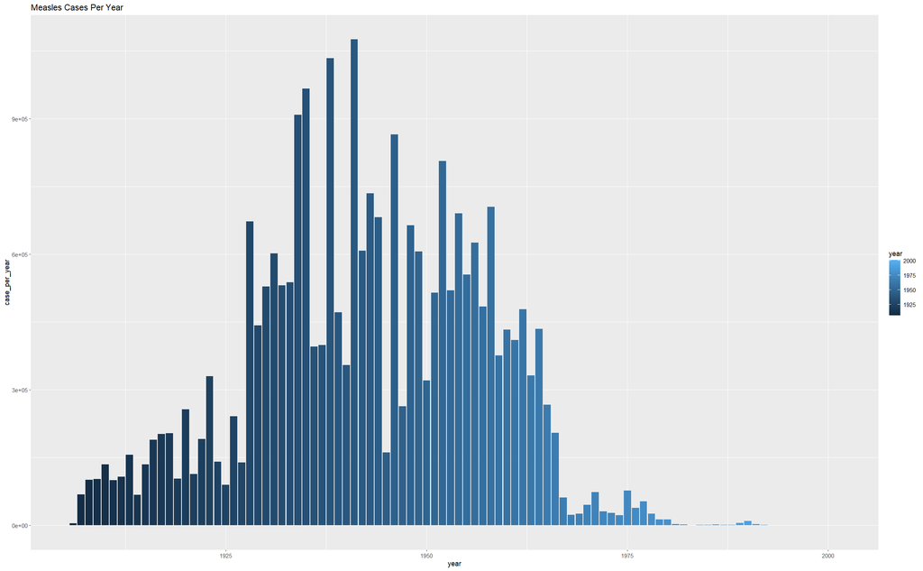

```r
ggplot(usMeaslesPerYear, mapping = aes(x = year, y = case_per_year, fill = year)) +
  geom_bar(stat = "identity") +
  labs(title = "Measles Cases Per Year")
```

We take a closer look at the 1980s to 2000s which are hard to see on the barplot

```r
usMeasles80s <- usMeaslesPerYear %>%
                filter(year >= 1981 & year <= 2001)
```

We use filter() function to get data from the year 1981 to 2001, save it in the usMeasles80s dataframe and take a look at it

```r
usMeasles80s
```

| year | case_per_year |
| --- | --- |
| 1981 | 3154 |
| 1982 | 1739 |
| 1983 | 584 |
| 1984 | 1297 |
| 1985 | 835 |
| 1986 | 2248 |
| 1987 | 1410 |
| 1988 | 1665 |
| 1989 | 5169 |
| 1990 | 9907 |

[output cut: 11 more lines]

We use ggplot to visualize the data and save it into the usMeasles80sPlot dataframe

```r
usMeasles80sPlot <- ggplot(usMeasles80s, aes(x = year, y = case_per_year, fill = year)) +
  geom_area() +
  geom_line() +
    labs(title = "Measles Cases Per Year 1981-2000")
```

We checkout the usMeasles80sPlot and can see that there was a slight peak in cases in the late 80s

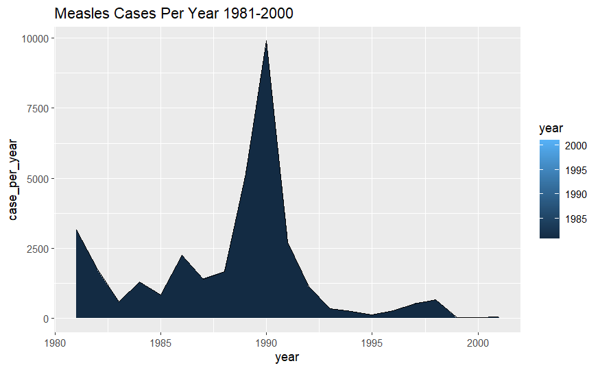

```r
usMeasles80sPlot
```

4.1.3 **Data Loading and Clean-Up of WHO vaccination data**

We got some data on measles vaccinations from the WHO website in excel format. To open it, we install the readxl package

```r
#install.packages("readxl")
```

We load our readxl package

```r
library(readxl)
```

We load our excel data into the measlesVacc dataframe initally using the absolute path.

```r
measlesVacc <- read_excel("C:/Users/hp/Downloads/data viz/measles_vaccination1.xlsx")
```

We convert our excel data into csv data

```r
write.csv(measlesVacc, "measles_vaccination1.csv")
```

Note That: We manually cleaned up the measles_vaccination1.csv file with our text editor, removed unwanted meta data and renamed the file measles_vaccination3.csv

```r
measlesVacc2 <- read.csv("measles_vaccination3.csv")
```

We read the csv data and save it into the measlesVacc2 data frame

```r
measlesVacc2
```

|  | CountryName | CountryCode | Indicator.Name | Indicator.Code | X1960 | X1961 | X1962 | X1963 | X1964 | X1965 | X1966 | X1967 | X1968 | X1969 | X1970 | X1971 | X1972 | X1973 | X1974 | X1975 | X1976 | X1977 | X1978 | X1979 | X1980 | X1981 | X1982 | X1983 | X1984 | … |
| --- | --- | --- | --- | --- | --- | --- | --- | --- | --- | --- | --- | --- | --- | --- | --- | --- | --- | --- | --- | --- | --- | --- | --- | --- | --- | --- | --- | --- | --- | --- |
| 4 | Aruba | ABW | Immunization, measles (% of children ages 12-23 months) | SH.IMM.MEAS | NA | NA | NA | NA | NA | NA | NA | NA | NA | NA | NA | NA | NA | NA | NA | NA | NA | NA | NA | NA | NA | NA | NA | NA | NA | … |
| 5 | Africa Eastern and Southern | AFE | Immunization, measles (% of children ages 12-23 months) | SH.IMM.MEAS | NA | NA | NA | NA | NA | NA | NA | NA | NA | NA | NA | NA | NA | NA | NA | NA | NA | NA | NA | NA | 9.1537736 | 16.91513865 | 19.5903450 | 31.517069 | 35.453956 | … |
| 6 | Afghanistan | AFG | Immunization, measles (% of children ages 12-23 months) | SH.IMM.MEAS | NA | NA | NA | NA | NA | NA | NA | NA | NA | NA | NA | NA | NA | NA | NA | NA | NA | NA | NA | NA | 11.0000000 | NA | 8.0000000 | 9.000000 | 14.000000 | … |
| 7 | Africa Western and Central | AFW | Immunization, measles (% of children ages 12-23 months) | SH.IMM.MEAS | NA | NA | NA | NA | NA | NA | NA | NA | NA | NA | NA | NA | NA | NA | NA | NA | NA | NA | NA | NA | 2.2133583 | 5.30788329 | 6.0098269 | 5.844995 | 12.405167 | … |
| 8 | Angola | AGO | Immunization, measles (% of children ages 12-23 months) | SH.IMM.MEAS | NA | NA | NA | NA | NA | NA | NA | NA | NA | NA | NA | NA | NA | NA | NA | NA | NA | NA | NA | NA | NA | NA | NA | 26.000000 | 35.000000 | … |
| 9 | Albania | ALB | Immunization, measles (% of children ages 12-23 months) | SH.IMM.MEAS | NA | NA | NA | NA | NA | NA | NA | NA | NA | NA | NA | NA | NA | NA | NA | NA | NA | NA | NA | NA | 90.0000000 | 90.00000000 | 93.0000000 | 96.000000 | 96.000000 | … |
| 10 | Andorra | AND | Immunization, measles (% of children ages 12-23 months) | SH.IMM.MEAS | NA | NA | NA | NA | NA | NA | NA | NA | NA | NA | NA | NA | NA | NA | NA | NA | NA | NA | NA | NA | NA | NA | NA | NA | NA | … |
| 11 | Arab World | ARB | Immunization, measles (% of children ages 12-23 months) | SH.IMM.MEAS | NA | NA | NA | NA | NA | NA | NA | NA | NA | NA | NA | NA | NA | NA | NA | NA | NA | NA | NA | NA | 14.7442495 | 15.92309373 | 22.6468523 | 26.075732 | 31.649972 | … |
| 12 | United Arab Emirates | ARE | Immunization, measles (% of children ages 12-23 months) | SH.IMM.MEAS | NA | NA | NA | NA | NA | NA | NA | NA | NA | NA | NA | NA | NA | NA | NA | NA | NA | NA | NA | NA | 34.0000000 | 42.00000000 | 41.0000000 | 51.000000 | 53.000000 | … |
| 13 | Argentina | ARG | Immunization, measles (% of children ages 12-23 months) | SH.IMM.MEAS | NA | NA | NA | NA | NA | NA | NA | NA | NA | NA | NA | NA | NA | NA | NA | NA | NA | NA | NA | NA | 61.0000000 | 77.00000000 | 67.0000000 | 67.000000 | 79.000000 | … |

[output cut: 256 more lines]

Our data contains vaccination data from many countries but we are only concerned with the United States so we filter out the data we need and save it in usVaccData

```r
library(dplyr)
 usVaccData <- filter(measlesVacc2, CountryCode == "USA")
```

We check our usVaccData

```r
usVaccData
```

|  | CountryName | CountryCode | Indicator.Name | Indicator.Code | X1960 | X1961 | X1962 | X1963 | X1964 | X1965 | X1966 | X1967 | X1968 | X1969 | X1970 | X1971 | X1972 | X1973 | X1974 | X1975 | X1976 | X1977 | X1978 | X1979 | X1980 | X1981 | X1982 | X1983 | X1984 | … |
| --- | --- | --- | --- | --- | --- | --- | --- | --- | --- | --- | --- | --- | --- | --- | --- | --- | --- | --- | --- | --- | --- | --- | --- | --- | --- | --- | --- | --- | --- | --- |
| 255 | United States | USA | Immunization, measles (% of children ages 12-23 months) | SH.IMM.MEAS | NA | NA | NA | NA | NA | NA | NA | NA | NA | NA | NA | NA | NA | NA | NA | NA | NA | NA | NA | NA | 86 | 97 | 97 | 98 | 98 | … |

We check the class of the variables in usVaccData

```r
sapply(usVaccData, class)
```

```
   CountryName    CountryCode Indicator.Name Indicator.Code          X1960          X1961          X1962
   "character"    "character"    "character"    "character"      "logical"      "logical"      "logical"
         X1963          X1964          X1965          X1966          X1967          X1968          X1969
     "logical"      "logical"      "logical"      "logical"      "logical"      "logical"      "logical"
         X1970          X1971          X1972          X1973          X1974          X1975          X1976
     "logical"      "logical"      "logical"      "logical"      "logical"      "logical"      "logical"
         X1977          X1978          X1979          X1980          X1981          X1982          X1983
     "logical"      "logical"      "logical"      "numeric"      "numeric"      "numeric"      "numeric"
         X1984          X1985          X1986          X1987          X1988          X1989          X1990
     "numeric"      "numeric"      "numeric"      "numeric"      "numeric"      "numeric"      "numeric"
         X1991          X1992          X1993          X1994          X1995          X1996          X1997
     "numeric"      "numeric"      "numeric"      "numeric"      "numeric"      "numeric"      "numeric"
         X1998          X1999          X2000          X2001          X2002          X2003          X2004
     "numeric"      "numeric"      "numeric"      "numeric"      "numeric"      "numeric"      "numeric"
         X2005          X2006          X2007          X2008          X2009          X2010          X2011
     "numeric"      "numeric"      "numeric"      "numeric"      "numeric"      "numeric"      "numeric"
         X2012          X2013          X2014          X2015          X2016          X2017          X2018
     "numeric"      "numeric"      "numeric"      "numeric"      "numeric"      "numeric"      "numeric"
         X2019          X2020          X2021          X2022
     "numeric"      "numeric"      "numeric"      "logical"
```

The early years in usVaccData have a lot of NA values so we select only data from 1981 onwards

```r
usVaccDataFinal <- select(usVaccData, -(X1960:X1980))
```

We checkout usVaccDataFinal

```r
usVaccDataFinal
```

|  | CountryName | CountryCode | Indicator.Name | Indicator.Code | X1981 | X1982 | X1983 | X1984 | X1985 | X1986 | X1987 | X1988 | X1989 | X1990 | X1991 | X1992 | X1993 | X1994 | X1995 | X1996 | X1997 | X1998 | X1999 | X2000 | X2001 | X2002 | X2003 | X2004 | X2005 | … |
| --- | --- | --- | --- | --- | --- | --- | --- | --- | --- | --- | --- | --- | --- | --- | --- | --- | --- | --- | --- | --- | --- | --- | --- | --- | --- | --- | --- | --- | --- | --- |
| 255 | United States | USA | Immunization, measles (% of children ages 12-23 months) | SH.IMM.MEAS | 97 | 97 | 98 | 98 | 97 | 97 | 82 | 98 | 94 | 90 | 87 | 83 | 84 | 89 | 88 | 91 | 91 | 92 | 92 | 91 | 91 | 91 | 93 | 93 | 92 | … |

Now we have immunization data from 1981 to 2001. However, the data is not entered a usable format for us. To fix this, we use tribble() function to create a new dataframe with the same information in usVaccDataFinal but in a format that is more amenable to use.

```r
usMeaslesVaccRate <- tribble(~years, ~immunization_rate,
        1981, 97,
        1982, 97,
        1983, 98,
        1984, 98,
        1985, 97,
        1986, 97,
        1987, 82,
        1988, 98,
        1989, 94,
        1990, 90,
        1991, 87,
        1992, 83,
        1993, 84,
        1994, 89,
        1995, 88,
        1996, 91,
        1997, 91,
        1998, 92,
        1999, 92,
        2000, 91,
        2001, 91)
```

We now have a new dataframe called usMeaslesVaccRate with two variables, years and immunization_rate

```r
usMeaslesVaccRate
```

| years | immunization_rate |
| --- | --- |
| 1981 | 97 |
| 1982 | 97 |
| 1983 | 98 |
| 1984 | 98 |
| 1985 | 97 |
| 1986 | 97 |
| 1987 | 82 |
| 1988 | 98 |
| 1989 | 94 |
| 1990 | 90 |

[output cut: 11 more lines]

We use a ggplot to visualize the data and save it in usMeaslesVaccRatePlot

```r
usMeaslesVaccRatePlot <- ggplot(usMeaslesVaccRate, aes(x = years, y = immunization_rate, fill = years)) +
  geom_area() +
  geom_line() +
      labs(title = "Measles Immunization Rate from Years 1981-2001")
```

4.1.4 **Data Analysis of our Measles Vaccination Dataset**

We chekout what the usMeaslesVaccRatePlot looks like. We can see that there is a small decline in the vaccination rate in the late 80s

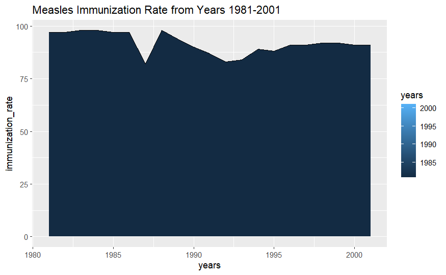

```r
usMeaslesVaccRatePlot
```

4.1.5 **Comparison of Measles Incidence Plot and Measles Vaccination Rate Plot**

```r
library(patchwork)
```

We compare both plots and can see that the sligh peak in masles cases in the late 80s overlaps with the slight decrease in vaccination rates in the late 80s

```r
usMeasles80sPlotAndusMeaslesVaccRatePlot <- usMeasles80sPlot + usMeaslesVaccRatePlot
```

|  | t | l | b | r |
| --- | --- | --- | --- | --- |
| 1: | 1 | 1 | 1 | 1 |
| 2: | 1 | 2 | 1 | 2 |

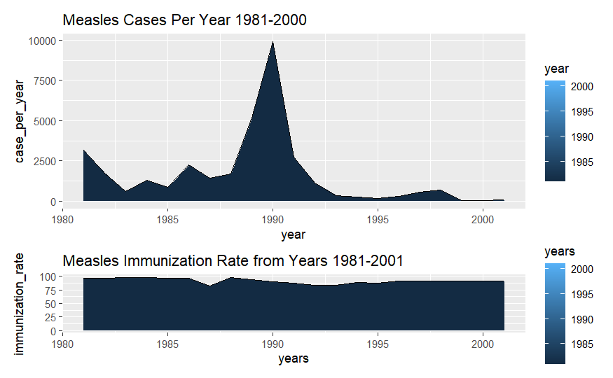

```r
usMeasles80sPlotAndusMeaslesVaccRatePlot + plot_layout(heights = c(3,1))
```

4.1.6. **Statistical Analysis of Measles Incidence Rate with Vaccination Rate**

First, we section some data that we need. We get the incidence of measles cases from 1931 to 2001. However, since we know our vaccination data lacks entries for the early periods of vaccination, ie, from 1963 to 1979, we have to remove those years from our incidence data too.

```r
usMeasles30s <- usMeaslesPerYear %>%
                filter(year >= 1931 & year <= 2001 & !(year >= 1963 & year <= 1979))
```

We know that before the introduction of the measles vaccine to the public in 1963, and again in 1968, there were no children vaccinated against measles. That means the vaccination rate against measles before 1963 is 0%.

```r
usMeaslesVaccRate30s <- tribble(~years, ~immunization_rate,
        1931, 0,
        1932, 0,
        1933, 0,
        1934, 0,
        1935, 0,
        1936, 0,
        1937, 0,
        1938, 0,
        1939, 0,
        1940, 0,
        1941, 0,
        1942, 0,
        1943, 0,
        1944, 0,
        1945, 0,
        1946, 0,
        1947, 0,
        1948, 0,
        1949, 0,
        1950, 0,
        1951, 0,
        1952, 0,
        1953, 0,
        1954, 0,
        1955, 0,
        1956, 0,
        1957, 0,
        1958, 0,
        1959, 0,
        1960, 0,
        1961, 0,
        1962, 0,
        1963, NA,
        1964, NA,
        1965, NA,
        1966, NA,
        1967, NA,
        1968, NA,
        1969, NA,
        1970, NA,
        1971, NA,
        1972, NA,
        1973, NA,
        1974, NA,
        1975, NA,
        1976, NA,
        1977, NA,
        1978, NA,
        1979, NA,
        1980, 97,
        1981, 97,
        1982, 97,
        1983, 98,
        1984, 98,
        1985, 97,
        1986, 97,
        1987, 82,
        1988, 98,
        1989, 94,
        1990, 90,
        1991, 87,
        1992, 83,
        1993, 84,
        1994, 89,
        1995, 88,
        1996, 91,
        1997, 91,
        1998, 92,
        1999, 92,
        2000, 91,
        2001, 91)
```

We’ve assinged 0% as the immunization rate for years before 1963, and NA for the years 1963 to 1979 because even though vaccinations were available in those years, we do not have the data. But to proceed, we must remove the NA values from our data.

```r
usMeaslesVaccRate30s <- usMeaslesVaccRate30s %>%
                        filter(!is.na(immunization_rate))
```

We check out usMeasles30s

```r
usMeasles30s
```

| year | case_per_year |
| --- | --- |
| 1931 | 601992 |
| 1932 | 531668 |
| 1933 | 538323 |
| 1934 | 909022 |
| 1935 | 966618 |
| 1936 | 395417 |
| 1937 | 399589 |
| 1938 | 1034314 |
| 1939 | 471445 |
| 1940 | 354968 |

[output cut: 44 more lines]

We check out usMeaslesVaccRate30s

```r
usMeaslesVaccRate30s
```

| years | immunization_rate |
| --- | --- |
| 1931 | 0 |
| 1932 | 0 |
| 1933 | 0 |
| 1934 | 0 |
| 1935 | 0 |
| 1936 | 0 |
| 1937 | 0 |
| 1938 | 0 |
| 1939 | 0 |
| 1940 | 0 |

[output cut: 44 more lines]

We do a correlation test using Pearson’s product moment test. The value of our correlation coefficient is -0.8 which indiates that there is a negative correlation between the incidence of measles cases and immunization rate. Our p value also indicates that the correlation is statistically significant.

```r
cor.test(usMeasles30s$case_per_year, usMeaslesVaccRate30s$immunization_rate)
```

```
    Pearson's product-moment correlation

data:  usMeasles30s$case_per_year and usMeaslesVaccRate30s$immunization_rate
t = -12.273, df = 52, p-value < 2.2e-16
alternative hypothesis: true correlation is not equal to 0
95 percent confidence interval:
 -0.9180150 -0.7728455
sample estimates:
       cor
-0.8621872
```

4.1.7 **Modeling**

We want to model our y dependent variable (case_per_year) on our independent variable x variable (immunization_rate). for this, we create a new dataframe called modelData

```r
modelData <- usMeasles30s %>%
              select(y = case_per_year) %>%
              mutate(x = usMeaslesVaccRate30s$immunization_rate)
```

We fit a linear regression on our modelData

```r
modelDataMod <- lm(y ~ x, data = modelData)
```

We find the intercept and coefficient

```r
coef(modelDataMod)
```

```
(Intercept)           x
 585953.839   -6326.999
```

To make predictions, we need to load the modelr pacakge

```r
library(modelr)
```

We use the data_grid() function to generate an evenly spaced grid of values that covers the region where out data lies

```r
grid <- modelData %>%
        data_grid(x)
grid
```

| x |
| --- |
| 0 |
| 82 |
| 83 |
| 84 |
| 87 |
| 88 |
| 89 |
| 90 |
| 91 |
| 92 |

[output cut: 3 more lines]

Next we use the add_predictions function to add predictions

```r
grid <- grid %>%
        add_predictions(modelDataMod)
grid
```

| x | pred |
| --- | --- |
| 0 | 585953.839 |
| 82 | 67139.949 |
| 83 | 60812.950 |
| 84 | 54485.951 |
| 87 | 35504.955 |
| 88 | 29177.957 |
| 89 | 22850.958 |
| 90 | 16523.959 |
| 91 | 10196.961 |
| 92 | 3869.962 |

[output cut: 3 more lines]

We plot our predictions using ggplot2

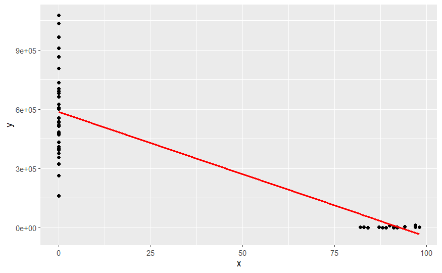

```r
ggplot(modelData, aes(x)) +
  geom_point(aes(y = y)) +
  geom_line(aes(y = pred), data = grid, color = "red", size = 1)
```

We add residuals to tell us what our model has missed

```r
modelData <- modelData %>%
             add_residuals(modelDataMod)
modelData
```

| y | x | resid |
| --- | --- | --- |
| 601992 | 0 | 16038.161 |
| 531668 | 0 | -54285.839 |
| 538323 | 0 | -47630.839 |
| 909022 | 0 | 323068.161 |
| 966618 | 0 | 380664.161 |
| 395417 | 0 | -190536.839 |
| 399589 | 0 | -186364.839 |
| 1034314 | 0 | 448360.161 |
| 471445 | 0 | -114508.839 |
| 354968 | 0 | -230985.839 |

[output cut: 44 more lines]

We visualize our residuals with a frequency polygon

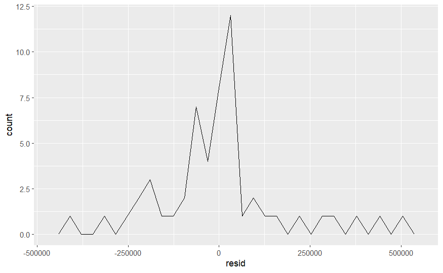

```r
ggplot(modelData, aes(resid)) +
  geom_freqpoly()
```

5. **RESULTS**

   We had to get a bit creative with our statistical analysis in 4.1.6.However, assigning 0% as the vaccination rates for the years before the licensing of any measles vaccine makes sense. And when we do that, we can see that there is a strong negative correlation between measles incidence and vaccination rates.
7. **CONCLUSION**

   Our aim is to present the data to vaccination skeptics and show them how the discovery and introduction of the measles vaccine caused a sharp decrease in the incidence of measles in the late 60s. Millions of lives have been saved by the measles vaccine since its discovery. If measles vaccination rates continue to fall in the aftermath of the covid-19 pandemic, it will have real consequences for public health.
8. **CITATIONS**
- [0]Centers for Disease Control and Prevention Measles cases in 2022, from https://www.cdc.gov/measles/cases-outbreaks.html
- [1] World Health Organization. (n.d.). Measles. Retrieved June 18, 2023, from https://www.who.int/news-room/fact-sheets/detail/measles
- [2] Robert T. Perry , Neal A. Halsey, The Clinical Significance of Measles: A Review, The Journal of Infectious Diseases, Volume 189, Issue Supplement_1, May 2004, Pages S4–S16, https://doi.org/10.1086/377712
- [3]World Health Organization. (n.d.). Measles. Retrieved June 18, 2023, from https://www.who.int/news-room/fact-sheets/detail/measles
- [4] Lena H Sun. The Washington Post. (2022, December 26). Vaccine hesitancy: Measles, chickenpox, polio, and flu. Retrieved June 18, 2023, from https://www.washingtonpost.com/health/2022/12/26/vaccine-hesitancy-measles-chickenpox-polio-flu
- [5]“Measles vaccine.” Wikipedia, The Free Encyclopedia. Wikimedia Foundation, Inc. Retrieved June 18, 2023, from https://en.wikipedia.org/wiki/Measles_vaccine